# Creating a topicbrowser

First, get Topicmodel data. To create a topicbrowser three elements are required: 1. tokens: A data.frame in which each row is a token (word or lemma) in an article. There should be a column for unique article ids. Rows should be ordered in the same order as the words occur in the articles. To create token data, see manuals for tokenization. It is advised to use natural language processing (NLP) techniques to get stemmed or lemmatized tokens, and to be able to filter on part-of-speech tags. This can be obtained using free software such as nlp.core (english), frog (Dutch) and parzu (German). 2. meta: A data.frame giving additional information per article. There should be an 'id' column that matches the article id column in the tokens data.frame. Label columns representing article date 'date' and use the `Date` format. 3. topicmodel: A topicmodel in the format of the `topicmodels` package. See the `corpustools` package for a manual on how to create a topicmodel based on a the data.frame with tokens.

```r
library(topicbrowser)
data(sotu)
head(sotu.tokens)
```

```
##         word sentence  pos      lemma offset       aid id pos1 freq
## 1         It        1  PRP         it      0 111541965  1    O    1
## 2         is        1  VBZ         be      3 111541965  2    V    1
## 3        our        1 PRP$         we      6 111541965  3    O    1
## 4 unfinished        1   JJ unfinished     10 111541965  4    A    1
## 5       task        1   NN       task     21 111541965  5    N    1
## 6         to        1   TO         to     26 111541965  6    ?    1
```

```r
head(sotu.meta)
```

```
##          id   medium     headline       date
## 1 111541965 Speeches Barack Obama 2013-02-12
## 2 111541995 Speeches Barack Obama 2013-02-12
## 3 111542001 Speeches Barack Obama 2013-02-12
## 4 111542006 Speeches Barack Obama 2013-02-12
## 5 111542013 Speeches Barack Obama 2013-02-12
## 6 111542018 Speeches Barack Obama 2013-02-12
```

```r
sotu.m
```

```
## A LDA_Gibbs topic model with 10 topics.
```

The first step for creating the topicbrowser is to use the clusterinfo function. This creates a single list in which relevant information is combined. (This approach makes it easier to manage visualizations).

```r
info = clusterinfo(sotu.m, sotu.tokens$lemma, sotu.tokens$aid, meta = sotu.meta,
    words = sotu.tokens$word, date_interval = "year")
names(info)
```

```
## [1] "tokens"          "wordassignments" "topics_per_doc"  "topics_per_term"
## [5] "topic_ids"       "meta"            "date_interval"
```

We can now already create a default topicbrowser using the createTopicBrowser function.

```r
createTopicBrowser(info)
```

```
## Writing html to /tmp/Rtmp9lqX6m/topicbrowser_4ff6bb548b4.html
## Rendering overview
```

[output not shown]

[output cut: 38 more lines]

[output not shown]

```
## Rendering topic 1
```

```
## Rendering topic 2
```

```
## Rendering topic 3
## Rendering topic 4
```

```
## Rendering topic 5
```

```
## Rendering topic 6
```

```
## Rendering topic 7
```

```
## Rendering topic 8
## Rendering topic 9
## Rendering topic 10
```

Pretty cool. But you might want to use different visualizations instead of the default wordcloud and time graph. For this purpose, we can use the `plotfunction` parameters of the createTopicBrowser function. These parameters take as input special, standardized functions, that produce a plot based on the `info` object as created by the clusterinfo function. We developed several of such `plotfunction` functions (all starting with `pf.`) and it is easy to implement new ones yourself.

Here are some of the `plotfunction` defaults included in this package. The input for these functions is the `info` object, and an integer representing which topic to plot.

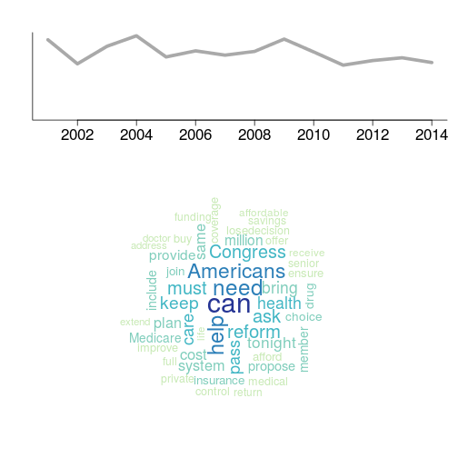

```r
pf.wordcloud_time(info, topic_nr = 2)  # the default visualization used for plotfunction.overview: wordcloud and time graph
```

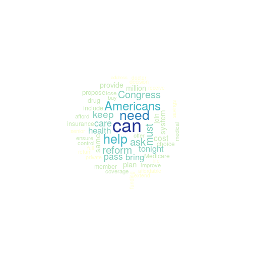

```r
pf.wordcloud(info, topic_nr = 2)  # the default first visualization used for plotfunction.pertopic: wordcloud
```

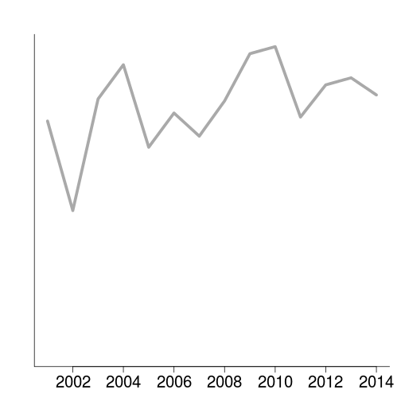

```r
pf.time(info, topic_nr = 2)  # the default second visualization used for plotfunction.pertopic: time graph
```

Note that the intervalls for the time graph are based on the date_interval parameter in the info object. This can either be changed when creating the object using the clusterinfo function, or afterwards.

We mentioned that pf.wordcloud is the first, and pf.time is the second default visualization in the plotfunction.pertopic. This is because multiple plot functions can be used here. See the following silly but illustrative example

```r
createTopicBrowser(info, plotfunction.pertopic = list(pf.time, pf.wordcloud,
    pf.time, pf.wordcloud))
```

```
## Writing html to /tmp/Rtmp9lqX6m/topicbrowser_4ff50d12e18.html
## Rendering overview
```

[output not shown]

[output cut: 32 more lines]

[output not shown]

```
## Rendering topic 1
```

```
## Rendering topic 2
```

```
## Rendering topic 3
## Rendering topic 4
```

[output not shown]

```
## Rendering topic 5
```

```
## Rendering topic 6
```

[output not shown]

```
## Rendering topic 7
```

```
## Rendering topic 8
## Rendering topic 9
## Rendering topic 10
```

There are now 4 visualizations in the topic pages: first pf.time, then pf.wordcloud, and then another pf.time and another pf.wordcloud.